# R Notebook

# Homework Week 05 - Day 1: Introductory ggplot2 Homework

```r
library(tidyverse)
library(tidyverse)
library(CodeClanData)
```

```r
#following data required:
view(qb_revenue_breakdown)
view(qb_monthly_sales)
view(qb_competitors)
view(qb_device_data)
```

## Question 1 -

Take the data in the dataset `qb_revenue_breakdown` and make a stacked bar chart showing the sources of revenue across the two years in the dataset.

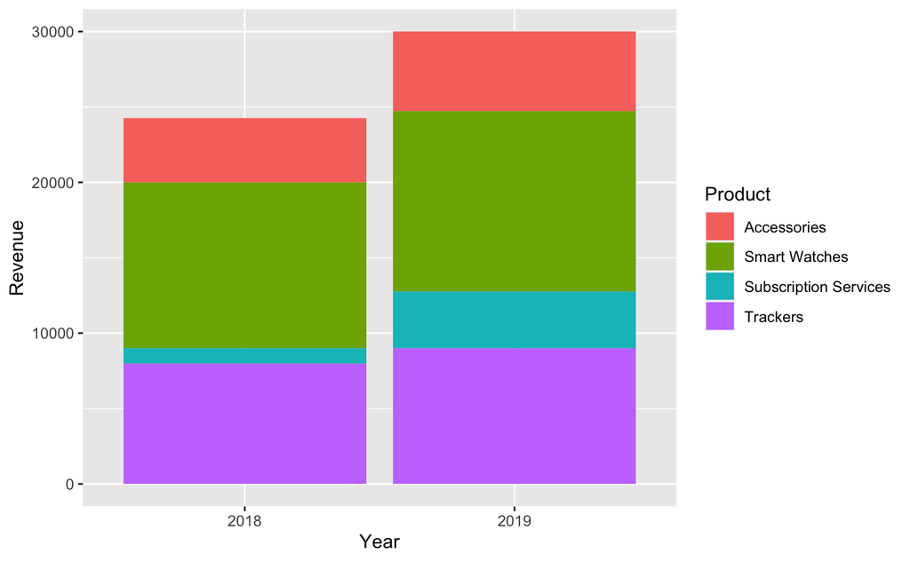

## Question 2 -

Make a line chart showing monthly sales of the “flagship product” - the ‘KwikBit Unit 1’ - over the last year. This data is inside `qb_monthly_sales`, but you will need to use `filter()` or `subset()` (base `R)`.

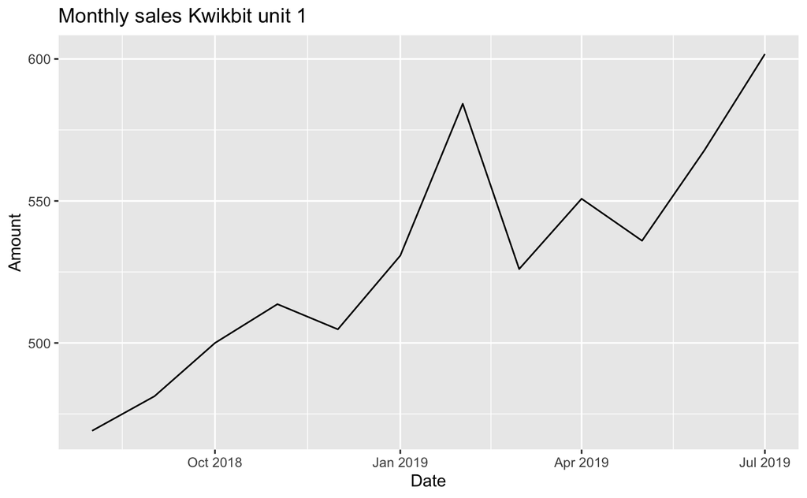

## Question 3 -

Make a line chart showing monthly revenue and costs over the last year. This data is also in `qb_monthly_sales`.

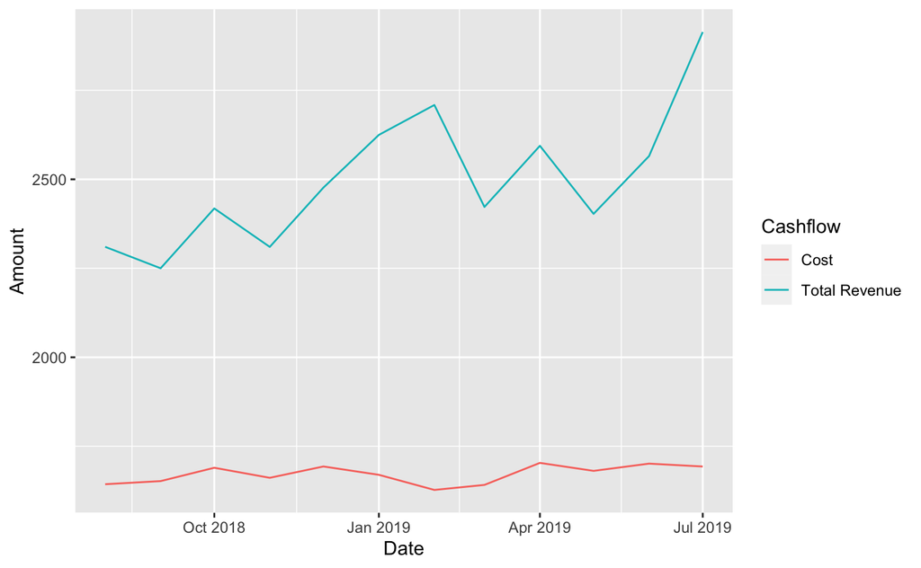

## Question 4 -

Show annual sales of personal fitness trackers over the last 5 years broken down by company as a ribbon plot (use `geom_area`). This data is in `qb_competitors`.

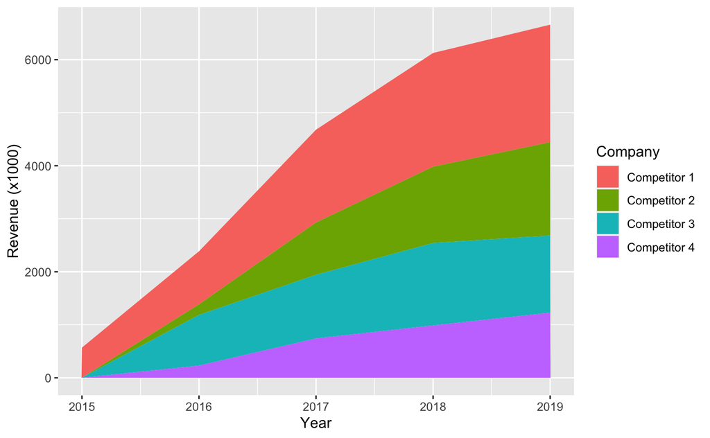

## Question 5 -

Now show the sales from the four competitors as a line graph. Include an extra layer that shows the data points used to make the lines.

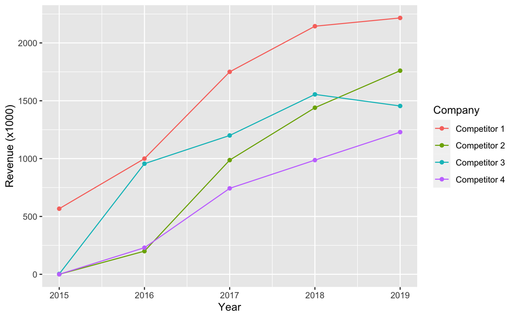

## Question 6 -

Now the company wants to compare the number of steps that their device counts vs. their competitors. Make a line graph of the number of steps throughout time, and use faceting to compare between companies and people. The data for this is in `qb_device_data`.

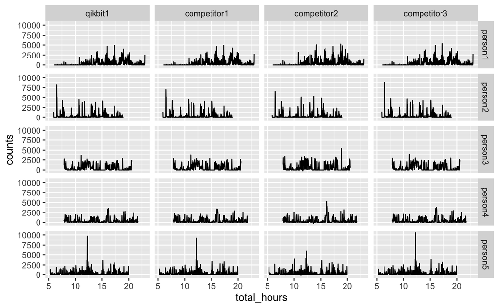

## Part 2: Question 1

Take the plots that you produced in part one and now polish them by:

1. Adding appropriate labels
2. Changing the scales and coordinates when appropriate.
3. Applying a unified theme, which is described below:
- Graphs should have white backgrounds, and use colour sparingly.
- There should be faint grid lines.
- Font sizes should be ~12pt although titles should be slightly larger and axis labels can be slightly smaller.
- All plots should use colours from the following company colour scheme. col_scheme <- c(“#E89FE9”, “#50434F”, “#B6A7B5”, “#F9A472”, “#BD7040”)

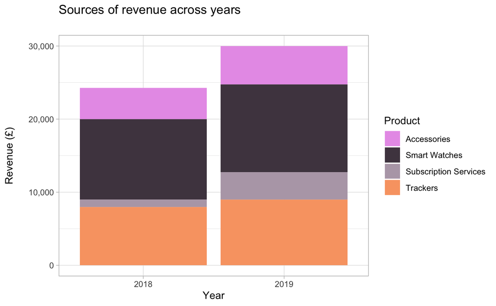

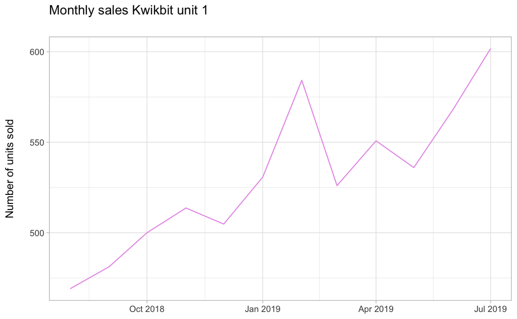

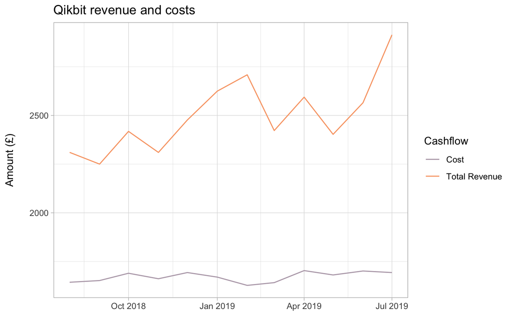

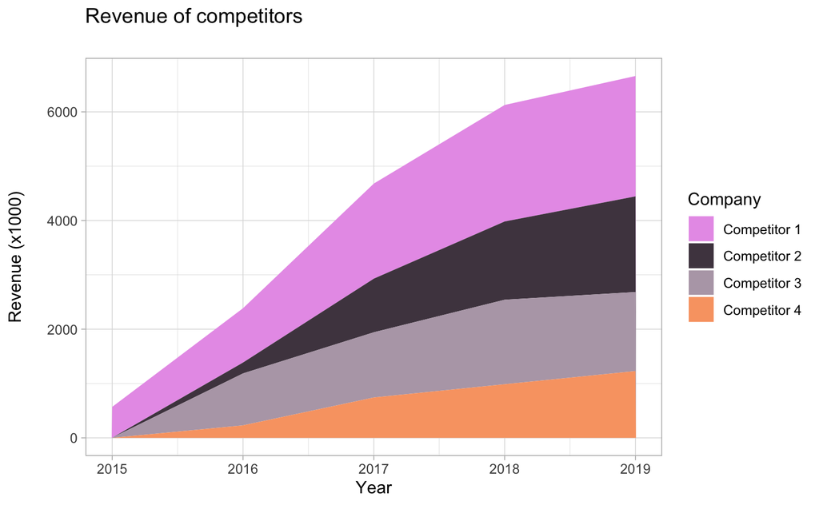

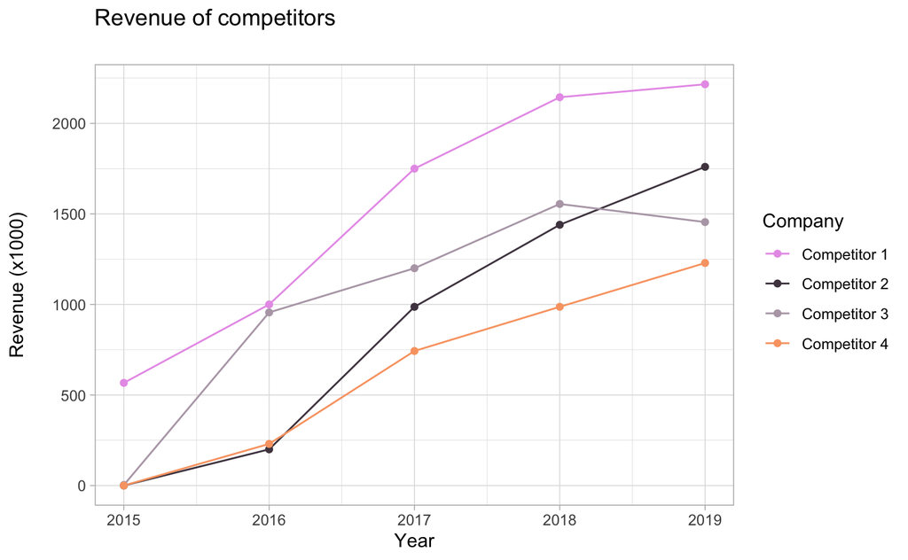

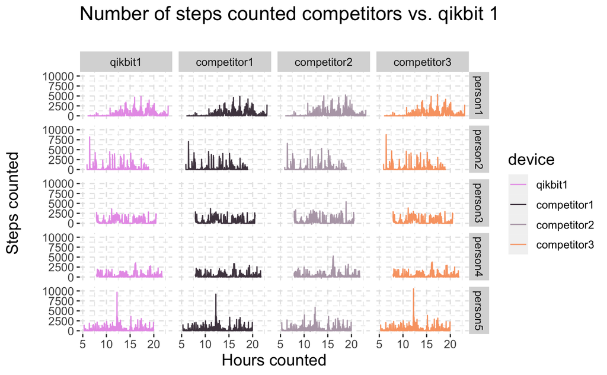

```r
#Further useful:
scale_x_date(date_breaks = "1 month", date_labels = "%d-%b-%y") # (to split dates by month in the labels)
```